# Modelamiento y pronóstico de la llegada mensual de visitantes extranjeros no residentes a Colombia (2015–2025)

Inferencia Avanzada y Análisis Multivariado — Unidad 4 · Actividad sumativa

Noviembre de 2026

**Fuente de datos.** Datos Abiertos Colombia (datos.gov.co), conjunto *Extranjeros No Residentes* (id `7wm8-w5ad`), publicado por el Ministerio de Comercio, Industria y Turismo con registros de Migración Colombia. El archivo original (466.915 registros por año, mes, ciudad de destino y país de residencia) se agregó a un total nacional mensual en `data/turistas_colombia_mensual.csv`. El código para reconstruir ese CSV desde la fuente está en el Anexo, al final del documento.

**Corte de los datos.** La versión del conjunto utilizada llega hasta julio de 2025. Por eso el pronóstico de agosto de 2025 a julio de 2026 es un **ejercicio retrospectivo**: se estima con la información disponible hasta julio de 2025, como se habría hecho en ese momento, y después se contrasta con las cifras oficiales publicadas para agosto y septiembre de 2025.

**Paquetes necesarios** (instalar una sola vez en RStudio): `install.packages(c("forecast", "tseries", "knitr", "jsonlite", "rmarkdown"))`. Tras presionar **Knit**, copiar el HTML generado a `docs/index.html` para actualizar el reporte publicado.

# 1 Carga y preparación de la serie

```r
library(forecast)   # descomposición, suavizamiento exponencial, Holt-Winters, métricas de error
library(tseries)    # pruebas de estacionariedad ADF y KPSS
library(knitr)      # tablas
library(jsonlite)   # exportación de resultados

GRIS <- "grey55"; ROJO <- "#b03a2e"
MESES <- c("Ene","Feb","Mar","Abr","May","Jun","Jul","Ago","Sep","Oct","Nov","Dic")
```

```r
datos <- read.csv("data/turistas_colombia_mensual.csv")
datos$fecha <- as.Date(datos$fecha)
stopifnot(!any(is.na(datos$visitantes)))            # sin valores faltantes

# Objeto ts mensual: inicia en enero de 2015, frecuencia 12
serie <- ts(datos$visitantes, start = c(2015, 1), frequency = 12)
cat("Observaciones:", length(serie), "| desde", format(min(datos$fecha), "%Y-%m"),
    "hasta", format(max(datos$fecha), "%Y-%m"), "\n")
```

```
## Observaciones: 127 | desde 2015-01 hasta 2025-07
```

```r
summary(serie)
```

```
##    Min. 1st Qu.  Median    Mean 3rd Qu.    Max.
##     408  175146  217086  229001  311996  451522
```

```r
# Regímenes: la pandemia (mar-2020 a dic-2021) es un cambio estructural
pre  <- window(serie, end = c(2019, 12))            # 60 meses prepandemia
post <- window(serie, start = c(2022, 1))           # pospandemia (ene-2022 a jul-2025)
miles <- function(x) x / 1000
```

# 2 Análisis exploratorio

## 2.1 Serie completa, tendencia y choque de la pandemia

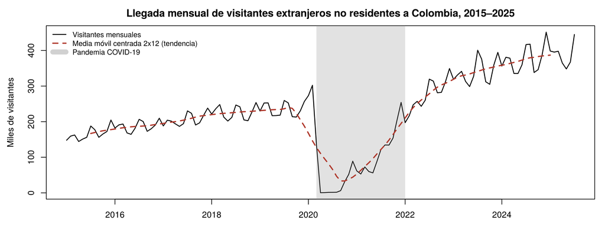

```r
par(mar = c(3, 4.5, 2.5, 1), cex = 0.85)
plot(miles(serie), lwd = 1.4, ylab = "Miles de visitantes", xlab = "",
     main = "Llegada mensual de visitantes extranjeros no residentes a Colombia, 2015–2025")
rect(2020 + 2/12, -50, 2022, 600, col = adjustcolor(GRIS, 0.25), border = NA)   # pandemia
lines(miles(ma(serie, order = 12, centre = TRUE)), col = ROJO, lwd = 2, lty = 2)  # tendencia
legend("topleft", bty = "n", cex = 0.85, lwd = c(1.4, 2, 8), lty = c(1, 2, 1),
       col = c("black", ROJO, adjustcolor(GRIS, 0.4)),
       legend = c("Visitantes mensuales", "Media móvil centrada 2x12 (tendencia)", "Pandemia COVID-19"))
```

```r
anual <- aggregate(as.numeric(serie), by = list(Año = floor(time(serie))), FUN = sum)
names(anual)[2] <- "Total"
anual$Meses <- as.numeric(table(floor(time(serie))))
anual$`Crecimiento %` <- round(c(NA, diff(anual$Total) / head(anual$Total, -1) * 100), 1)
anual_tab <- anual; anual_tab$Año <- as.character(anual_tab$Año)   # el año sin separador de miles
kable(anual_tab, format.args = list(big.mark = ".", decimal.mark = ","), caption = "Total anual (2025 solo hasta julio)")
```

Total anual (2025 solo hasta julio)

| Año | Total | Meses | Crecimiento % |
| --- | --- | --- | --- |
| 2015 | 1.984.744 | 12 | NA |
| 2016 | 2.241.054 | 12 | 12,9 |
| 2017 | 2.465.815 | 12 | 10,0 |
| 2018 | 2.709.043 | 12 | 9,9 |
| 2019 | 2.814.025 | 12 | 3,9 |
| 2020 | 893.865 | 12 | -68,2 |
| 2021 | 1.395.265 | 12 | 56,1 |
| 2022 | 3.279.931 | 12 | 135,1 |
| 2023 | 4.077.639 | 12 | 24,3 |
| 2024 | 4.504.530 | 12 | 10,5 |
| 2025 | 2.717.214 | 7 | -39,7 |

```r
cat("Mínimo:", min(serie), "en", format(datos$fecha[which.min(serie)], "%Y-%m"),
    "| Máximo:", max(serie), "en", format(datos$fecha[which.max(serie)], "%Y-%m"), "\n")
```

```
## Mínimo: 408 en 2020-04 | Máximo: 451522 en 2024-12
```

**Lectura.** Se distinguen tres tramos: (1) **crecimiento sostenido** 2015–2019; (2) **colapso** por el cierre de fronteras en 2020 (mínimo de 408 visitantes en abril de 2020) y reapertura gradual en 2021; (3) **recuperación y nuevos récords** desde 2022, con un máximo histórico en diciembre de 2024.

## 2.2 Estacionalidad

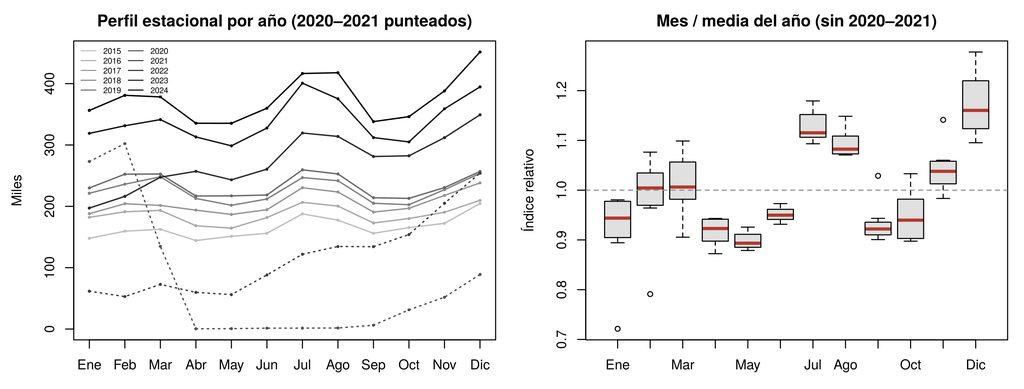

```r
mat <- matrix(as.numeric(window(serie, end = c(2024, 12))), nrow = 12)   # años completos 2015-2024
colnames(mat) <- 2015:2024
# Índice relativo: valor del mes / media de su año (se excluyen 2020-2021 por el choque)
normal <- mat[, !(colnames(mat) %in% c("2020", "2021"))]
relativo <- sweep(normal, 2, colMeans(normal), "/")

par(mfrow = c(1, 2), mar = c(3, 4.5, 2.5, 1), cex = 0.8)
tonos <- grey(seq(0.75, 0, length.out = ncol(mat)))
matplot(1:12, miles(mat), type = "o", pch = 16, cex = 0.5, col = tonos,
        lty = ifelse(colnames(mat) %in% c("2020", "2021"), 3, 1), lwd = 1.3,
        xaxt = "n", xlab = "", ylab = "Miles", main = "Perfil estacional por año (2020–2021 punteados)")
axis(1, 1:12, MESES); legend("topleft", legend = colnames(mat), col = tonos, lty = 1, ncol = 2, cex = 0.6, bty = "n")
boxplot(t(relativo), names = MESES, col = "grey88", medcol = ROJO, ylab = "Índice relativo",
        main = "Mes / media del año (sin 2020–2021)")
abline(h = 1, lty = 2, col = GRIS)
```

```r
round(rowMeans(relativo), 3) |> setNames(MESES)
```

```
##   Ene   Feb   Mar   Abr   May   Jun   Jul   Ago   Sep   Oct   Nov   Dic
## 0.919 0.986 1.012 0.917 0.898 0.951 1.127 1.093 0.933 0.947 1.043 1.173
```

**Lectura.** El patrón se repite todos los años: **picos en diciembre, julio y agosto** (vacaciones de fin de año y de verano en el hemisferio norte, de donde llega la mayoría de visitantes) y en marzo (Semana Santa en algunos años), y **valles en mayo, septiembre y abril**.

```r
# ¿La amplitud estacional crece con el nivel? Criterio para elegir modelo aditivo o multiplicativo
amp <- data.frame(Año = as.integer(colnames(normal)), Media = colMeans(normal),
                  Rango = apply(normal, 2, function(x) max(x) - min(x)),
                  Desv = apply(normal, 2, sd))
amp$`CV %` <- round(amp$Desv / amp$Media * 100, 1)
amp_tab <- amp; amp_tab$Año <- as.character(amp_tab$Año)
kable(amp_tab, digits = 0, row.names = FALSE, format.args = list(big.mark = ".", decimal.mark = ","))
```

| Año | Media | Rango | Desv | CV % |
| --- | --- | --- | --- | --- |
| 2015 | 165.395 | 60.289 | 17.579 | 11 |
| 2016 | 186.754 | 45.319 | 14.470 | 8 |
| 2017 | 205.485 | 51.380 | 17.544 | 8 |
| 2018 | 225.754 | 52.060 | 19.095 | 8 |
| 2019 | 234.502 | 46.541 | 18.843 | 8 |
| 2022 | 273.328 | 152.030 | 44.957 | 16 |
| 2023 | 339.803 | 102.117 | 34.908 | 10 |
| 2024 | 375.378 | 116.185 | 37.580 | 10 |

```r
corr_amp <- cor(amp$Media, amp$Rango)
cat("Correlación entre nivel medio anual y rango estacional:", round(corr_amp, 3), "\n")
```

```
## Correlación entre nivel medio anual y rango estacional: 0.7
```

Cuando el nivel se duplica (de unos 165 mil en 2015 a 375 mil en 2024), el **rango estacional también se duplica**, mientras que el coeficiente de variación se mantiene alrededor de 8–10 %. Es decir, las oscilaciones son **proporcionales al nivel**: evidencia a favor del modelo **multiplicativo**.

## 2.3 Ciclos y ruido

La serie cubre poco más de diez años, insuficiente para identificar ciclos económicos formales (que duran varios años). La oscilación de mayor plazo es el **choque de la pandemia**, que se trata como un cambio estructural y no como un ciclo regular. El ruido se analiza con los residuos de la descomposición (sección 3).

## 2.4 Estacionariedad

```r
# ADF:  H0 = la serie tiene raíz unitaria (NO es estacionaria)
# KPSS: H0 = la serie ES estacionaria
# Nota: tseries reporta los p-valores de KPSS truncados en 0,01 y 0,10.
prueba <- function(x, nombre) {
  x <- na.omit(x)
  p_adf  <- suppressWarnings(adf.test(x)$p.value)
  p_kpss <- suppressWarnings(kpss.test(x, null = "Level")$p.value)
  concl <- if (p_adf < 0.05 && p_kpss > 0.05) "Estacionaria" else
           if (p_adf > 0.05 && p_kpss < 0.05) "No estacionaria" else "No concluyente"
  data.frame(Serie = nombre, n = length(x), `p ADF` = round(p_adf, 3),
             `p KPSS` = round(p_kpss, 3), Conclusión = concl, check.names = FALSE)
}
lpre <- log(pre)
estac <- rbind(
  prueba(pre, "Prepandemia (nivel)"),
  prueba(lpre, "Prepandemia (log)"),
  prueba(diff(lpre), "Prepandemia Δ log"),
  prueba(diff(diff(lpre), lag = 12), "Prepandemia Δ Δ12 log"),
  prueba(post, "Pospandemia (nivel)"),
  prueba(diff(diff(log(post)), lag = 12), "Pospandemia Δ Δ12 log"))
kable(estac)
```

| Serie | n | p ADF | p KPSS | Conclusión |
| --- | --- | --- | --- | --- |
| Prepandemia (nivel) | 60 | 0.025 | 0.010 | No concluyente |
| Prepandemia (log) | 60 | 0.053 | 0.010 | No estacionaria |
| Prepandemia Δ log | 59 | 0.010 | 0.100 | Estacionaria |
| Prepandemia Δ Δ12 log | 47 | 0.010 | 0.100 | Estacionaria |
| Pospandemia (nivel) | 43 | 0.088 | 0.010 | No estacionaria |
| Pospandemia Δ Δ12 log | 30 | 0.013 | 0.078 | Estacionaria |

```r
cat("Diferencias regulares sugeridas (ndiffs):", ndiffs(lpre),
    "| diferencias estacionales sugeridas (nsdiffs):", nsdiffs(lpre), "\n")
```

```
## Diferencias regulares sugeridas (ndiffs): 1 | diferencias estacionales sugeridas (nsdiffs): 1
```

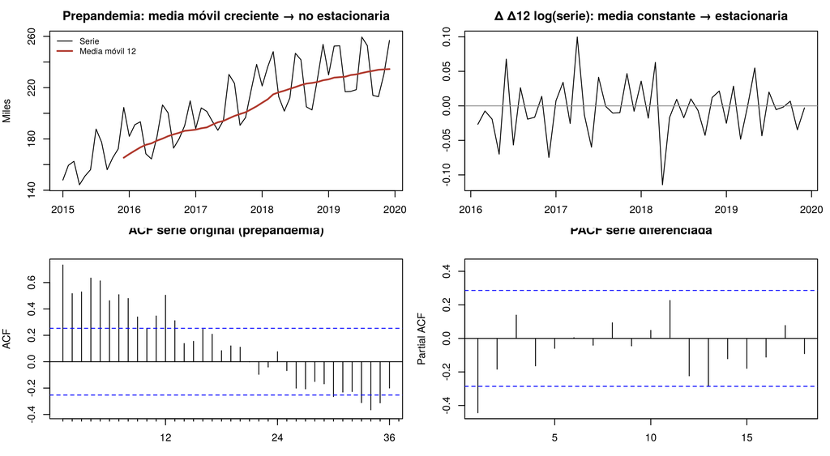

```r
par(mfrow = c(2, 2), mar = c(3, 4, 2.5, 1), cex = 0.75)
plot(miles(pre), ylab = "Miles", xlab = "", main = "Prepandemia: media móvil creciente → no estacionaria")
lines(miles(stats::filter(pre, rep(1/12, 12), sides = 1)), col = ROJO, lwd = 2)
legend("topleft", c("Serie", "Media móvil 12"), col = c("black", ROJO), lwd = c(1, 2), bty = "n", cex = 0.8)
dd <- diff(diff(lpre), lag = 12)
plot(dd, ylab = "", xlab = "", main = "Δ Δ12 log(serie): media constante → estacionaria"); abline(h = 0, col = GRIS)
Acf(pre, lag.max = 36, main = "ACF serie original (prepandemia)")
Pacf(dd, lag.max = 18, main = "PACF serie diferenciada")
```

# 3 Descomposición de la serie

La descomposición clásica exige una serie sin rupturas, por lo que se aplica al **régimen prepandemia (2015–2019, 60 meses)** y, para comprobar la estabilidad del patrón, al **régimen pospandemia (2022–2025)**. Se comparan los dos modelos:

- Aditivo: **Y(t) = T(t) + S(t) + R(t)**, con amplitud estacional constante.
- Multiplicativo: **Y(t) = T(t) × S(t) × R(t)**, con amplitud proporcional al nivel.

```r
dec_add <- decompose(pre, type = "additive")
dec_mul <- decompose(pre, type = "multiplicative")
r_add <- na.omit(dec_add$random); r_mul <- na.omit(dec_mul$random)
t_add <- na.omit(dec_add$trend);  t_mul <- na.omit(dec_mul$trend)
comp <- data.frame(
  Modelo = c("Aditivo", "Multiplicativo"),
  `Desv. residuo (% del nivel)` = c(sd(r_add / t_add) * 100, sd(r_mul - 1) * 100),
  `p Ljung-Box (12 rezagos)` = c(Box.test(r_add, lag = 12, type = "Ljung-Box")$p.value,
                                Box.test(r_mul, lag = 12, type = "Ljung-Box")$p.value),
  check.names = FALSE)
kable(comp, digits = 3)
```

| Modelo | Desv. residuo (% del nivel) | p Ljung-Box (12 rezagos) |
| --- | --- | --- |
| Aditivo | 2.243 | 0.095 |
| Multiplicativo | 2.003 | 0.031 |

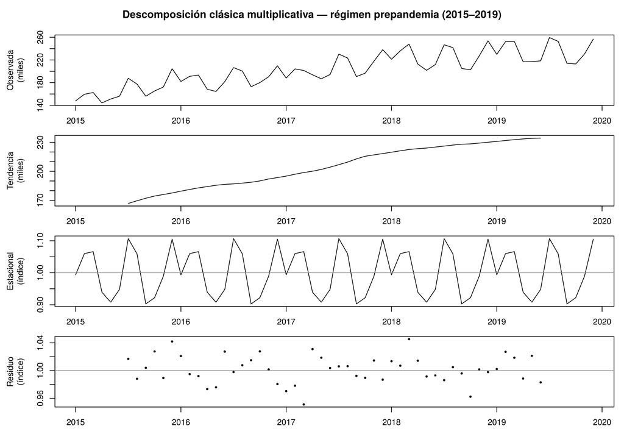

```r
par(mfrow = c(4, 1), mar = c(1.5, 5.5, 1.5, 1), oma = c(1.5, 0, 2, 0), cex = 0.8)   # margen izquierdo amplio para las etiquetas
plot(miles(pre), ylab = "Observada\n(miles)", xlab = "")
plot(miles(dec_mul$trend), ylab = "Tendencia\n(miles)", xlab = "")
plot(dec_mul$seasonal, ylab = "Estacional\n(índice)", xlab = ""); abline(h = 1, col = GRIS)
plot(dec_mul$random, type = "p", pch = 16, cex = 0.6, ylab = "Residuo\n(índice)", xlab = ""); abline(h = 1, col = GRIS)
mtext("Descomposición clásica multiplicativa — régimen prepandemia (2015–2019)", outer = TRUE, font = 2)
```

```r
pend_pre  <- coef(lm(t_mul ~ seq_along(t_mul)))[2]
dec_post  <- decompose(post, type = "multiplicative")
t_post    <- na.omit(dec_post$trend)
pend_post <- coef(lm(t_post ~ seq_along(t_post)))[2]
cat(sprintf("Tendencia prepandemia: +%s visitantes/mes (≈ %.1f %% anual sobre la media)\n",
            format(round(pend_pre), big.mark = ".", decimal.mark = ","), pend_pre * 12 / mean(t_mul) * 100))
```

```
## Tendencia prepandemia: +1.502 visitantes/mes (≈ 8.8 % anual sobre la media)
```

```r
cat(sprintf("Tendencia pospandemia: +%s visitantes/mes\n", format(round(pend_post), big.mark = ".", decimal.mark = ",")))
```

```
## Tendencia pospandemia: +3.338 visitantes/mes
```

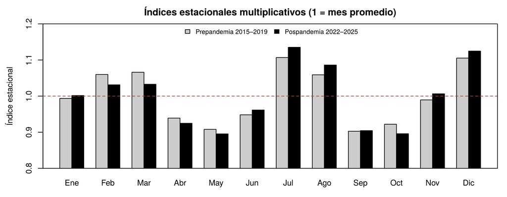

```r
ind <- data.frame(Mes = MESES, Prepandemia = dec_mul$figure, Pospandemia = dec_post$figure)
corr_ind <- cor(ind$Prepandemia, ind$Pospandemia)
par(mar = c(3, 4.5, 2.5, 1), cex = 0.8)
barplot(t(as.matrix(ind[, 2:3])), beside = TRUE, names.arg = MESES, col = c("grey80", "black"),
        ylim = c(0.8, 1.2), xpd = FALSE, ylab = "Índice estacional",
        main = "Índices estacionales multiplicativos (1 = mes promedio)")
abline(h = 1, col = ROJO, lty = 2); box()
legend("top", c("Prepandemia 2015–2019", "Pospandemia 2022–2025"), fill = c("grey80", "black"), horiz = TRUE, bty = "n", cex = 0.8)
```

```r
kable(ind, digits = 3, row.names = FALSE)
```

| Mes | Prepandemia | Pospandemia |
| --- | --- | --- |
| Ene | 0.994 | 1.002 |
| Feb | 1.060 | 1.031 |
| Mar | 1.066 | 1.033 |
| Abr | 0.939 | 0.925 |
| May | 0.908 | 0.895 |
| Jun | 0.948 | 0.961 |
| Jul | 1.107 | 1.135 |
| Ago | 1.059 | 1.086 |
| Sep | 0.903 | 0.904 |
| Oct | 0.922 | 0.896 |
| Nov | 0.989 | 1.006 |
| Dic | 1.105 | 1.125 |

```r
cat("Correlación entre los índices de ambos regímenes:", round(corr_ind, 3), "\n")
```

```
## Correlación entre los índices de ambos regímenes: 0.969
```

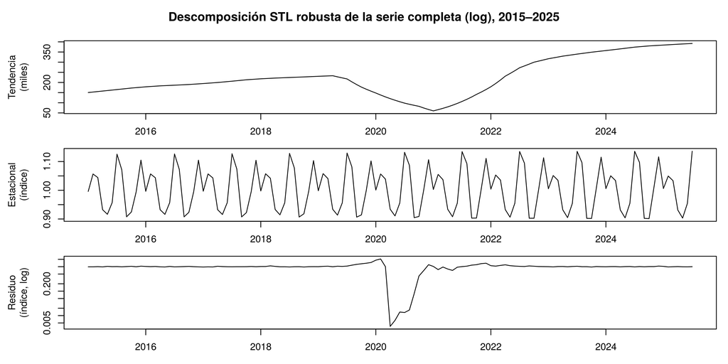

```r
# STL robusta sobre toda la serie en logaritmos: separa el choque del COVID de la estacionalidad
fit_stl <- stl(log(serie), s.window = 13, robust = TRUE)
par(mfrow = c(3, 1), mar = c(1.5, 5.5, 1.5, 1), oma = c(1.5, 0, 2, 0), cex = 0.8)   # margen izquierdo amplio para las etiquetas
plot(miles(exp(fit_stl$time.series[, "trend"])), ylab = "Tendencia\n(miles)", xlab = "")
plot(exp(fit_stl$time.series[, "seasonal"]), ylab = "Estacional\n(índice)", xlab = "")
plot(exp(fit_stl$time.series[, "remainder"]), ylab = "Residuo\n(índice, log)", xlab = "", log = "y")
mtext("Descomposición STL robusta de la serie completa (log), 2015–2025", outer = TRUE, font = 2)
```

**Interpretación de los componentes.**

- **Tendencia:** prepandemia crecía unos 1.502 visitantes por mes. Después de la pandemia el ritmo es mayor (3.338 por mes), aunque se desacelera en 2025.
- **Estacionalidad:** en diciembre y julio llegan 10–14 % más visitantes que en un mes promedio; en mayo y septiembre, cerca de 10 % menos. Los índices de los dos regímenes tienen una correlación de 0.969, así que el patrón estacional **sobrevivió intacto a la pandemia**.
- **Residuo:** representa alrededor del 2 % del nivel. En la STL concentra el choque de 2020–2021, lo que confirma que fue un evento atípico y no parte de la estacionalidad.

# 4 Técnicas de pronóstico

**Diseño.** Los modelos de suavizamiento dan más peso a lo reciente y quedarían distorsionados por los valores cercanos a cero de 2020–2021, así que se ajustan en el régimen pospandemia:

- **Entrenamiento:** ene-2022 a ene-2025 (37 meses).
- **Prueba:** feb-2025 a jul-2025 (6 meses que los modelos no ven).
- **Validación con origen móvil:** 8 orígenes, de jun-2024 a ene-2025, con horizonte de 1 a 6 meses.

```r
H <- 6
train <- window(post, end = c(2025, 1))
test  <- window(post, start = c(2025, 2))

ajustar <- function(y, h) {
  # Devuelve una lista con el pronóstico de cada método para h periodos
  list(
    "Ingenuo estacional"          = snaive(y, h = h)$mean,
    "Media móvil (k=3)"           = rep(mean(tail(y, 3)), h),
    "Media móvil (k=12)"          = rep(mean(tail(y, 12)), h),
    "SES (simple)"                = ses(y, h = h)$mean,
    "Holt (doble)"                = holt(y, h = h)$mean,
    "Holt-Winters aditivo"        = hw(y, h = h, seasonal = "additive")$mean,
    "Holt-Winters multiplicativo" = hw(y, h = h, seasonal = "multiplicative")$mean)
}
metr <- function(real, pred) {
  e <- as.numeric(real) - as.numeric(pred)
  c(MAE = mean(abs(e)), RMSE = sqrt(mean(e^2)), `MAPE %` = mean(abs(e / as.numeric(real))) * 100)
}
pron <- ajustar(train, H)
res <- t(sapply(pron, metr, real = test))

# Parámetros de suavizamiento estimados (alfa = nivel, beta = tendencia, gamma = estacionalidad)
params <- list(
  "SES (simple)" = ses(train, h = H)$model$par["alpha"],
  "Holt (doble)" = holt(train, h = H)$model$par[c("alpha", "beta")],
  "Holt-Winters aditivo" = hw(train, h = H, seasonal = "additive")$model$par[c("alpha", "beta", "gamma")],
  "Holt-Winters multiplicativo" = hw(train, h = H, seasonal = "multiplicative")$model$par[c("alpha", "beta", "gamma")])
params <- lapply(params, round, 3)
print(params)
```

```
## $`SES (simple)`
## alpha
## 0.467
##
## $`Holt (doble)`
## alpha  beta
## 0.088 0.054
##
## $`Holt-Winters aditivo`
## alpha  beta gamma
##   0.8   0.0   0.0
##
## $`Holt-Winters multiplicativo`
## alpha  beta gamma
## 0.460 0.065 0.000
```

```r
origenes <- seq(2024 + 5/12, 2025 + 0/12, by = 1/12)       # jun-2024 ... ene-2025
errores <- setNames(vector("list", length(pron)), names(pron))
for (o in origenes) {
  y_tr <- window(post, end = o)
  y_te <- window(post, start = o + 1/12)
  h <- min(H, length(y_te)); y_te <- y_te[1:h]
  f <- ajustar(y_tr, h)
  for (k in names(f)) errores[[k]] <- c(errores[[k]], abs((y_te - as.numeric(f[[k]])) / y_te) * 100)
}
cv <- sapply(errores, mean)
tabla <- data.frame(Método = rownames(res), round(res, 1), `MAPE % origen móvil` = round(cv[rownames(res)], 1),
                    check.names = FALSE)
tabla <- tabla[order(tabla$`MAPE % origen móvil`), ]
kable(tabla, row.names = FALSE, format.args = list(big.mark = ".", decimal.mark = ","))
```

| Método | MAE | RMSE | MAPE % | MAPE % origen móvil |
| --- | --- | --- | --- | --- |
| Holt-Winters multiplicativo | 38.993,3 | 40.970,4 | 10,0 | 5,6 |
| Holt-Winters aditivo | 51.690,7 | 52.477,5 | 13,6 | 7,1 |
| Ingenuo estacional | 18.697,5 | 20.331,8 | 4,8 | 7,7 |
| Holt (doble) | 32.031,2 | 41.011,2 | 8,8 | 8,2 |
| Media móvil (k=12) | 26.274,3 | 32.294,4 | 6,6 | 8,3 |
| Media móvil (k=3) | 36.988,1 | 40.946,2 | 9,9 | 8,4 |
| SES (simple) | 31.419,8 | 36.156,8 | 8,3 | 10,9 |

```r
MEJOR <- tabla$Método[1]
cat("Errores evaluados por método en origen móvil:", length(errores[[1]]), "| Mejor:", MEJOR, "\n")
```

```
## Errores evaluados por método en origen móvil: 48 | Mejor: Holt-Winters multiplicativo
```

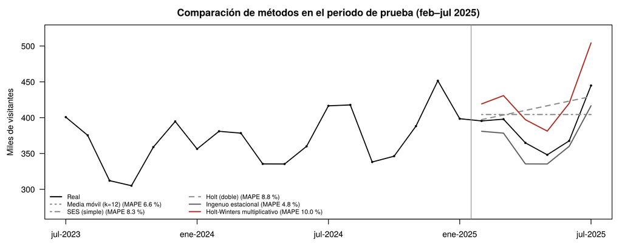

```r
par(mar = c(3, 4.5, 2.5, 1), cex = 0.8)
real <- window(post, start = c(2023, 7))
rango_y <- range(miles(real), sapply(pron, function(p) range(miles(p)))) * c(0.88, 1.03)   # eje que incluye todos los pronósticos y deja espacio a la leyenda
plot(miles(real), type = "o", pch = 16, cex = 0.6, lwd = 1.6, ylim = rango_y, las = 1, xaxt = "n",
     ylab = "Miles de visitantes", xlab = "", main = "Comparación de métodos en el periodo de prueba (feb–jul 2025)")
axis(1, at = seq(2023.5, 2025.5, by = 0.5),                          # eje en meses, no en años decimales
     labels = c("jul-2023", "ene-2024", "jul-2024", "ene-2025", "jul-2025"))
abline(v = 2025 + 1/12 - 0.04, col = GRIS)
est <- list("Media móvil (k=12)" = c(3, GRIS), "SES (simple)" = c(4, GRIS), "Holt (doble)" = c(2, GRIS),
            "Ingenuo estacional" = c(1, "grey40"), "Holt-Winters multiplicativo" = c(1, ROJO))
for (k in names(est)) lines(miles(pron[[k]]), lty = as.numeric(est[[k]][1]), col = est[[k]][2], lwd = 1.8)
legend("bottomleft", ncol = 2, bty = "n", cex = 0.75,
       legend = c("Real", sprintf("%s (MAPE %.1f %%)", names(est), res[names(est), "MAPE %"])),
       lty = c(1, sapply(est, function(e) as.numeric(e[1]))), col = c("black", sapply(est, `[`, 2)), lwd = 1.8)
```

```r
mod_hw <- hw(train, h = H, seasonal = "multiplicative")
lb <- Box.test(residuals(mod_hw), lag = 12, type = "Ljung-Box", fitdf = 3)
cat("Ljung-Box (12 rezagos) sobre residuos de Holt-Winters multiplicativo: p =", round(lb$p.value, 3), "\n")
```

```
## Ljung-Box (12 rezagos) sobre residuos de Holt-Winters multiplicativo: p = 0.045
```

```r
# p cercano a 0,05: queda algo de autocorrelación residual, una limitación del modelo (ver informe)
```

**Comparación.** En el corte único de 6 meses gana el **ingenuo estacional** porque 2025 casi repitió el patrón de 2024: el crecimiento interanual se moderó a entre 2 % y 9 %. En la validación con origen móvil, que promedia 48 errores en lugar de 6, **Holt-Winters multiplicativo** es el más preciso. SES, Holt y las medias móviles quedan atrás porque no modelan la estacionalidad, el componente dominante de la serie.

# 5 Pronóstico final a 12 meses (ago-2025 a jul-2026)

```r
fit_final <- hw(post, h = 12, seasonal = "multiplicative", level = c(80, 95))
fc <- data.frame(Mes = format(seq(as.Date("2025-08-01"), by = "month", length.out = 12), "%Y-%m"),
                 Pronóstico = round(as.numeric(fit_final$mean)),
                 `IC 95 % inf.` = round(as.numeric(fit_final$lower[, 2])),
                 `IC 95 % sup.` = round(as.numeric(fit_final$upper[, 2])), check.names = FALSE)
kable(fc, format.args = list(big.mark = ".", decimal.mark = ","))
```

| Mes | Pronóstico | IC 95 % inf. | IC 95 % sup. |
| --- | --- | --- | --- |
| 2025-08 | 431.926 | 380.803 | 483.049 |
| 2025-09 | 357.960 | 311.374 | 404.547 |
| 2025-10 | 358.595 | 307.537 | 409.653 |
| 2025-11 | 402.505 | 340.098 | 464.912 |
| 2025-12 | 450.709 | 374.943 | 526.474 |
| 2026-01 | 395.289 | 323.533 | 467.045 |
| 2026-02 | 408.870 | 329.018 | 488.723 |
| 2026-03 | 417.082 | 329.744 | 504.420 |
| 2026-04 | 383.480 | 297.651 | 469.308 |
| 2026-05 | 368.695 | 280.751 | 456.638 |
| 2026-06 | 395.244 | 295.041 | 495.446 |
| 2026-07 | 470.666 | 344.156 | 597.175 |

```r
cat("Total pronosticado ago-2025 a jul-2026:", format(round(sum(fc$Pronóstico)), big.mark = ".", decimal.mark = ","), "\n")
```

```
## Total pronosticado ago-2025 a jul-2026: 4.841.021
```

```r
cat("Total observado  ago-2024 a jul-2025:", format(sum(window(post, start = c(2024, 8))), big.mark = ".", decimal.mark = ","), "\n")
```

```
## Total observado  ago-2024 a jul-2025: 4.658.931
```

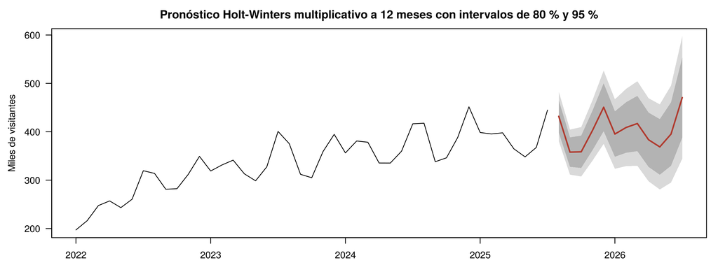

```r
par(mar = c(3, 4.5, 2.5, 1), cex = 0.8)
plot(fit_final, main = "Pronóstico Holt-Winters multiplicativo a 12 meses con intervalos de 80 % y 95 %",
     ylab = "Miles de visitantes", xlab = "", fcol = ROJO, shadecols = c("grey85", "grey70"), flwd = 2, yaxt = "n")
marcas <- pretty(c(0, max(fit_final$upper)))
axis(2, at = marcas, labels = marcas / 1000, las = 1)          # eje en miles, sin notación científica
```

## 5.1 Contraste con cifras oficiales publicadas después del corte de los datos

El MinCIT publicó acumulados posteriores a julio de 2025: 3.137.210 visitantes extranjeros entre enero y agosto (Portafolio, 2025) y 3.467.026 entre enero y septiembre (El Universal, 2025). Restando el acumulado de enero a julio de la serie se obtienen los valores de agosto y septiembre.

```r
acum_jul <- sum(window(serie, start = c(2025, 1)))
real_ago <- 3137210 - acum_jul; real_sep <- 3467026 - 3137210
expost <- data.frame(Mes = c("2025-08", "2025-09"), Real = c(real_ago, real_sep),
                     `Holt-Winters` = fc$Pronóstico[1:2],
                     `Ingenuo estacional` = as.numeric(window(post, start = c(2024, 8), end = c(2024, 9))),
                     check.names = FALSE)
expost$`Error HW %` <- round((expost$`Holt-Winters` / expost$Real - 1) * 100, 1)
expost$`Error ingenuo %` <- round((expost$`Ingenuo estacional` / expost$Real - 1) * 100, 1)
expost$`¿Real dentro del IC 95 %?` <- expost$Real >= fc$`IC 95 % inf.`[1:2] & expost$Real <= fc$`IC 95 % sup.`[1:2]
kable(expost, format.args = list(big.mark = ".", decimal.mark = ","))
```

| Mes | Real | Holt-Winters | Ingenuo estacional | Error HW % | Error ingenuo % | ¿Real dentro del IC 95 %? |
| --- | --- | --- | --- | --- | --- | --- |
| 2025-08 | 419.996 | 431.926 | 417.748 | 2,8 | -0,5 | TRUE |
| 2025-09 | 329.816 | 357.960 | 338.104 | 8,5 | 2,5 | TRUE |

## 5.2 Análisis complementario: ¿se recuperó la trayectoria prepandemia?

```r
hw_pre <- hw(pre, h = length(serie) - length(pre), seasonal = "multiplicative")
brecha <- (window(serie, start = c(2022, 1)) / window(hw_pre$mean, start = c(2022, 1)) - 1) * 100
brecha_anual <- tapply(brecha, floor(time(brecha)), mean)
round(brecha_anual, 1)
```

```
## 2022 2023 2024 2025
## -0.6 16.7 22.2 21.1
```

Un Holt-Winters ajustado solo con 2015–2019 representa la trayectoria que el turismo traía antes de la pandemia. Desde 2023 los valores observados la **superan** en 17 % a 22 %: el sector no solo se recuperó, sino que creció por encima de su tendencia previa.

# 6 Exportación de resultados

```r
resultados <- list(
  n = length(serie), anual = anual, amp = amp, corr_amp = corr_amp, estac = estac, comp = comp,
  pend_pre = unname(pend_pre), pend_pre_pct = unname(pend_pre * 12 / mean(t_mul) * 100), pend_post = unname(pend_post),
  indices = ind, corr_ind = corr_ind, tabla = tabla, params = params, mejor = MEJOR, lb_p = lb$p.value,
  fc = fc, fc_total = sum(fc$Pronóstico), obs_total_prev = sum(window(post, start = c(2024, 8))),
  expost = expost, brecha = as.list(round(brecha_anual, 1)),
  min = min(serie), max = max(serie))
write_json(resultados, "resultados_ts.json", auto_unbox = TRUE, digits = 6, pretty = TRUE)
```

# Anexo: reconstrucción del CSV desde la fuente original

```r
# Descarga el archivo original (copia del paquete ColombiAPI, datos de datos.gov.co id 7wm8-w5ad)
url <- "https://raw.githubusercontent.com/lightbluetitan/colombiapi/main/data/foreign_visitors_tbl_df.rda"
download.file(url, "visitantes.rda", mode = "wb")
load("visitantes.rda")                                   # crea el objeto foreign_visitors_tbl_df
crudo <- as.data.frame(foreign_visitors_tbl_df)
mes_num <- match(crudo$Mes, c("Ene","Feb","Mar","Abr","May","Jun","Jul","Ago","Sep","Oct","Nov","Dic"))
crudo$fecha <- as.Date(sprintf("%d-%02d-01", as.integer(crudo$Año), mes_num))
agregado <- aggregate(crudo[["Cant Extranjeros no Residentes"]], by = list(fecha = crudo$fecha), FUN = sum)
names(agregado)[2] <- "visitantes"
write.csv(agregado[order(agregado$fecha), ], "data/turistas_colombia_mensual.csv", row.names = FALSE)
```